# weightedsurv vignettes: every figure before (ac76f82) and after (HEAD) the vignette revision

### 18. Standard errors: weightedsurv (grey) and adjustedCurves (red)

vignettes/weightedsurv_examples.Rmd · chunk before: `unnamed-chunk-34 (figure 1)` · chunk after: `unnamed-chunk-35 (figure 1)` · image files differ

Before (ac76f82)

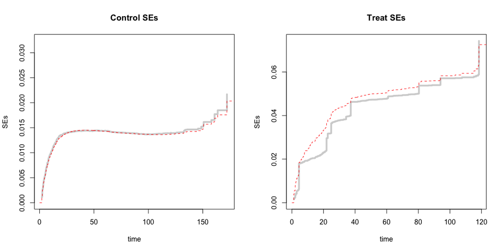

After (HEAD)

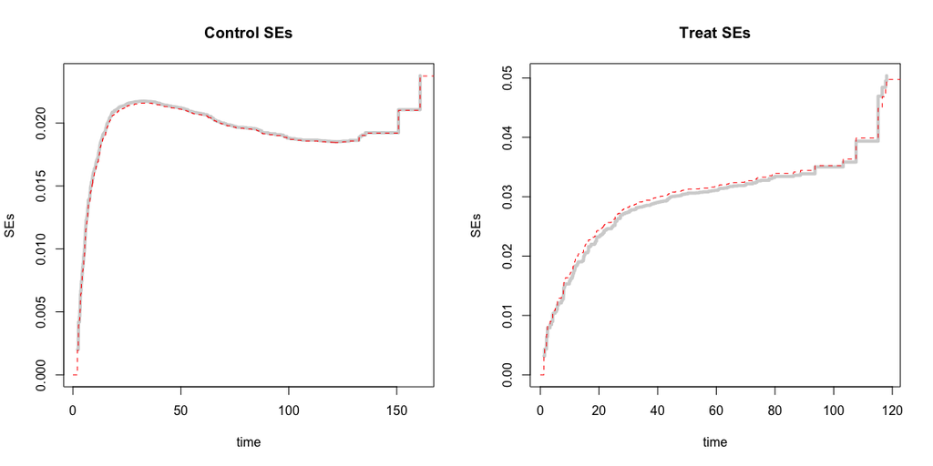

## vignettes/articles/martingale_resampling_applications.Rmd

### 1. GBSG K-M curves

vignettes/articles/martingale_resampling_applications.Rmd · chunk before: `gbsg-km (figure 1)` · chunk after: `gbsg-km (figure 1)` · image files byte-identical

Before (ac76f82)

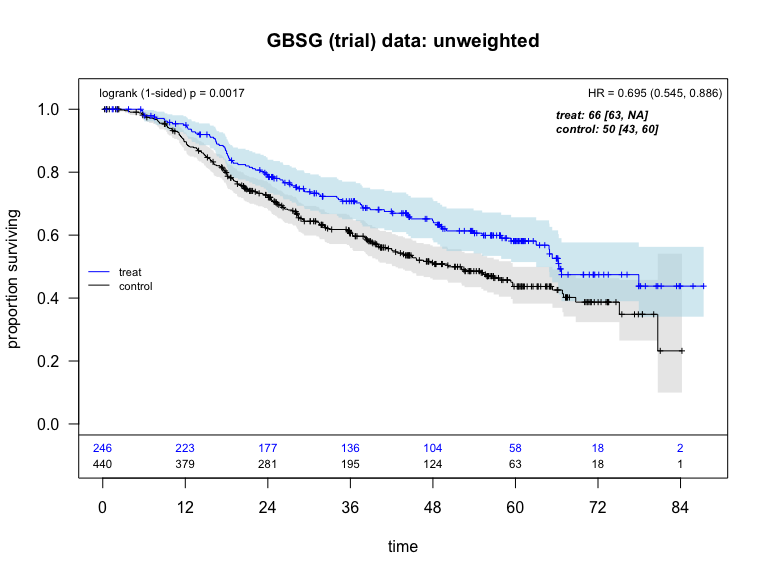

After (HEAD)

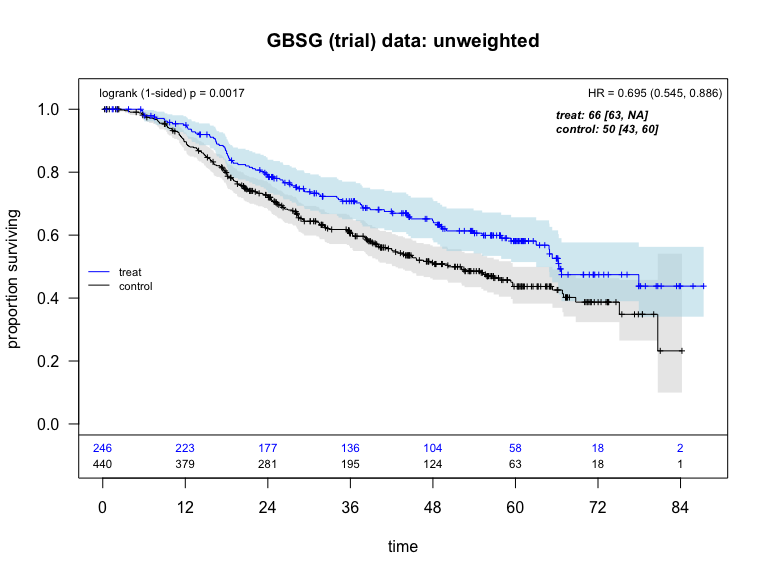

### 2. Rotterdam K-M curves, un-weighted and weighted

vignettes/articles/martingale_resampling_applications.Rmd · chunk before: `rotterdam-km (figure 1)` · chunk after: `rotterdam-km (figure 1)` · image files differ

Before (ac76f82)

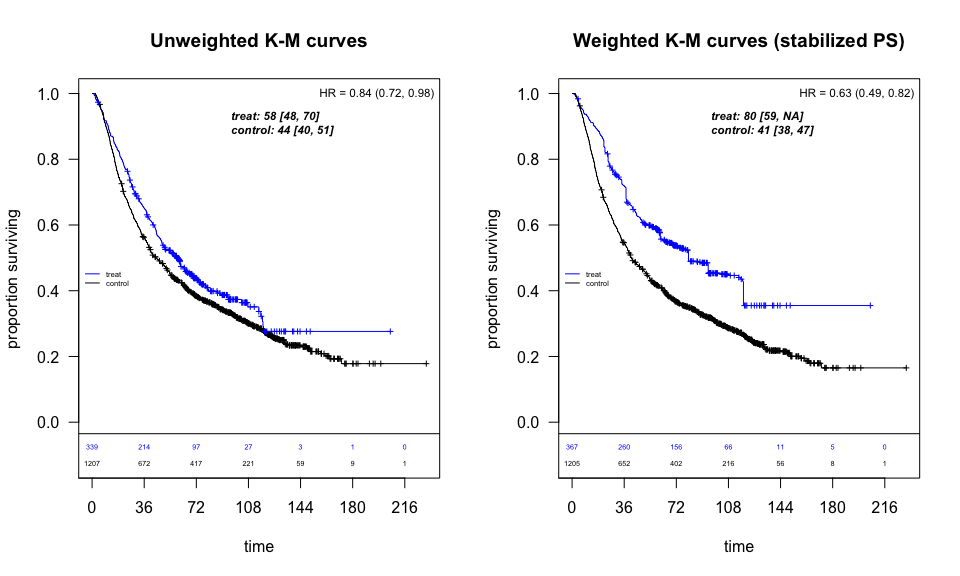

After (HEAD)

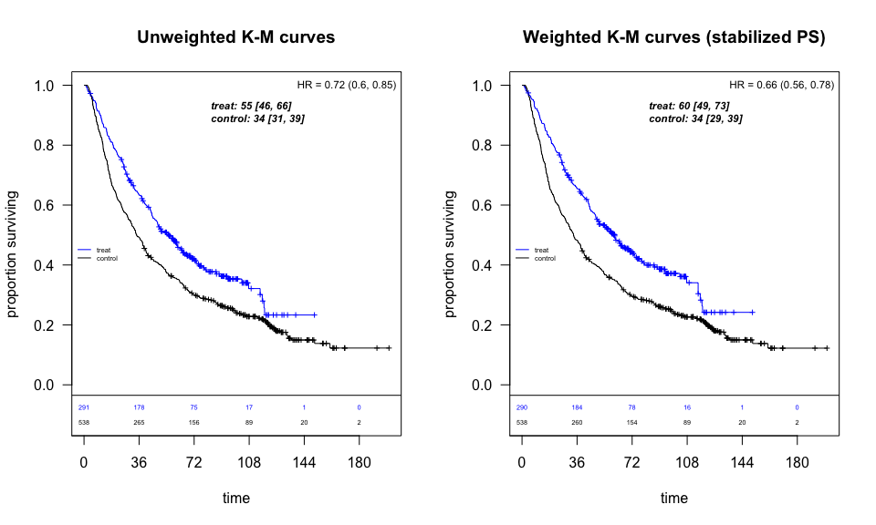

### 3. GBSG and Rotterdam weighted K-M curves

vignettes/articles/martingale_resampling_applications.Rmd · chunk before: `compare-km (figure 1)` · chunk after: `compare-km (figure 1)` · image files differ

Before (ac76f82)

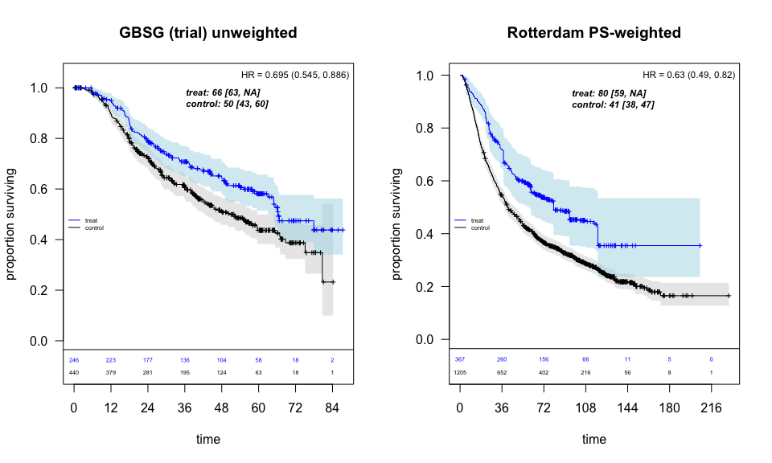

After (HEAD)

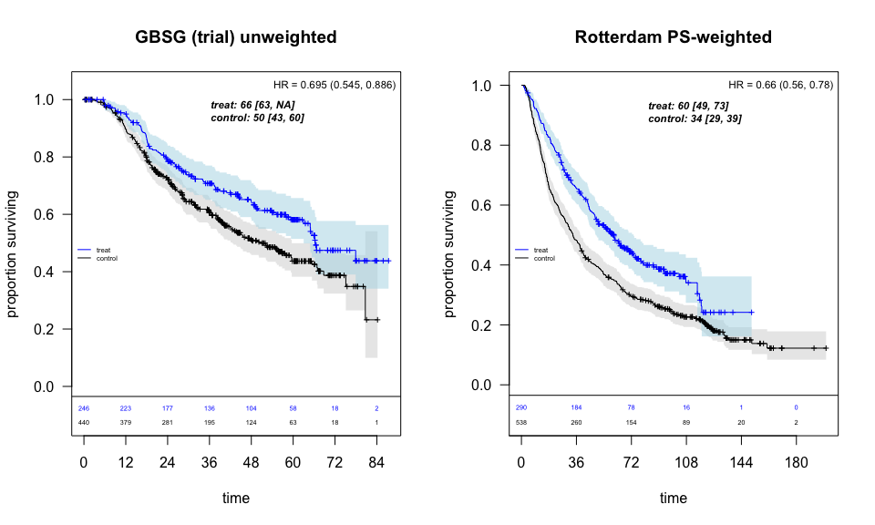

### 4. Rotterdam weighted survival difference: resampled curves

vignettes/articles/martingale_resampling_applications.Rmd · chunk before: `rotterdam-bands (figure 1)` · chunk after: `rotterdam-bands (figure 1)` · image files differ

Before (ac76f82)

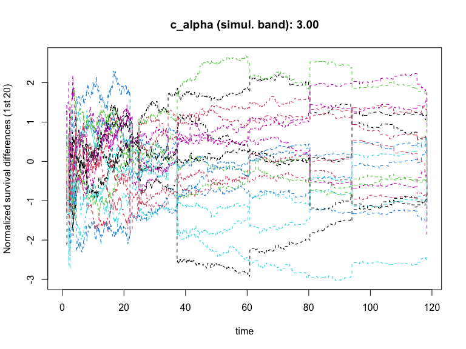

After (HEAD)

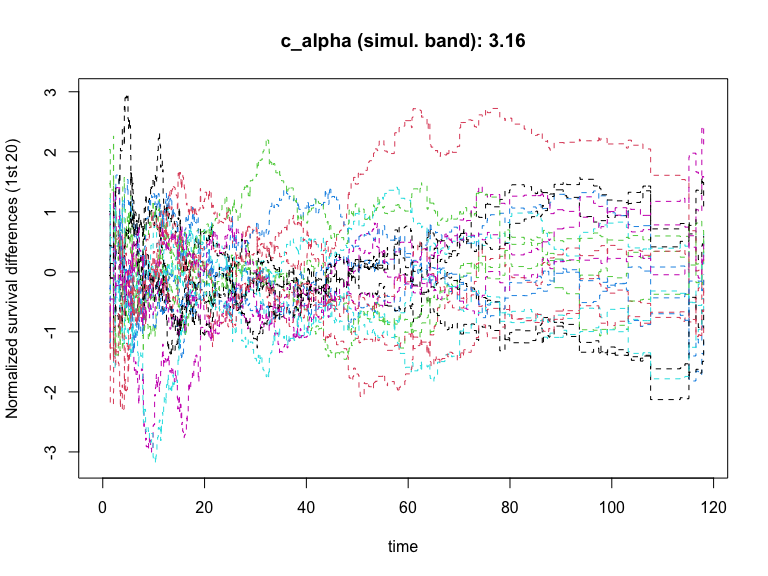

### 5. Rotterdam weighted survival difference: band

vignettes/articles/martingale_resampling_applications.Rmd · chunk before: `rotterdam-bands (figure 2)` · chunk after: `rotterdam-bands (figure 2)` · image files differ

Before (ac76f82)

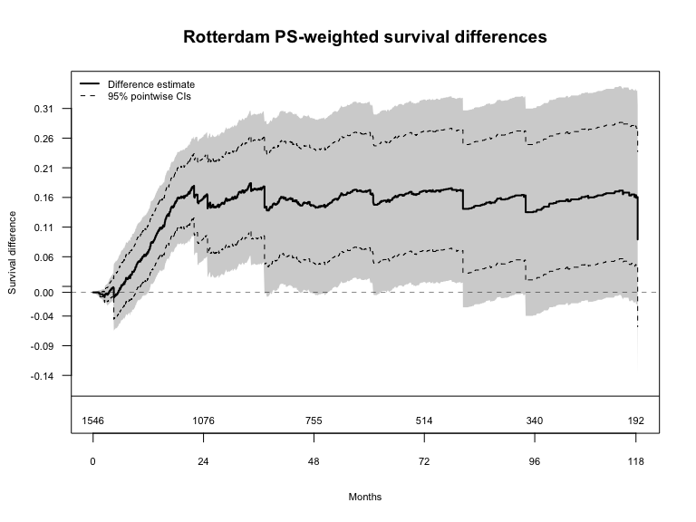

After (HEAD)

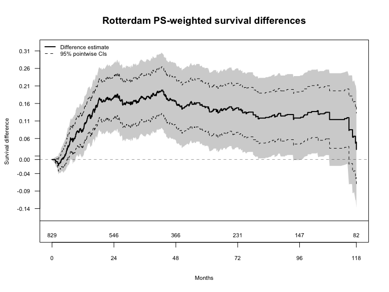

### 6. GBSG and Rotterdam weighted: survival-difference bands and cumulative RMST

vignettes/articles/martingale_resampling_applications.Rmd · chunk before: `rmst-combined (figure 1)` · chunk after: `rmst-combined (figure 1)` · image files differ

Before (ac76f82)

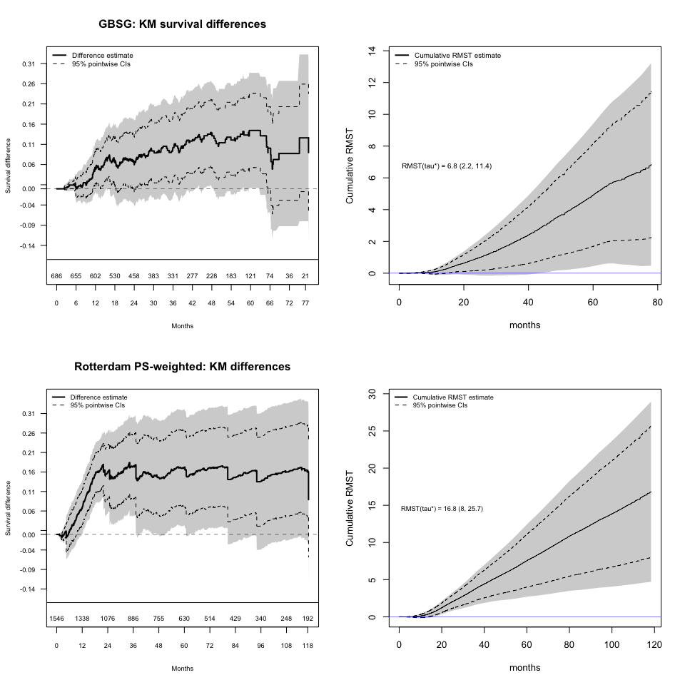

After (HEAD)

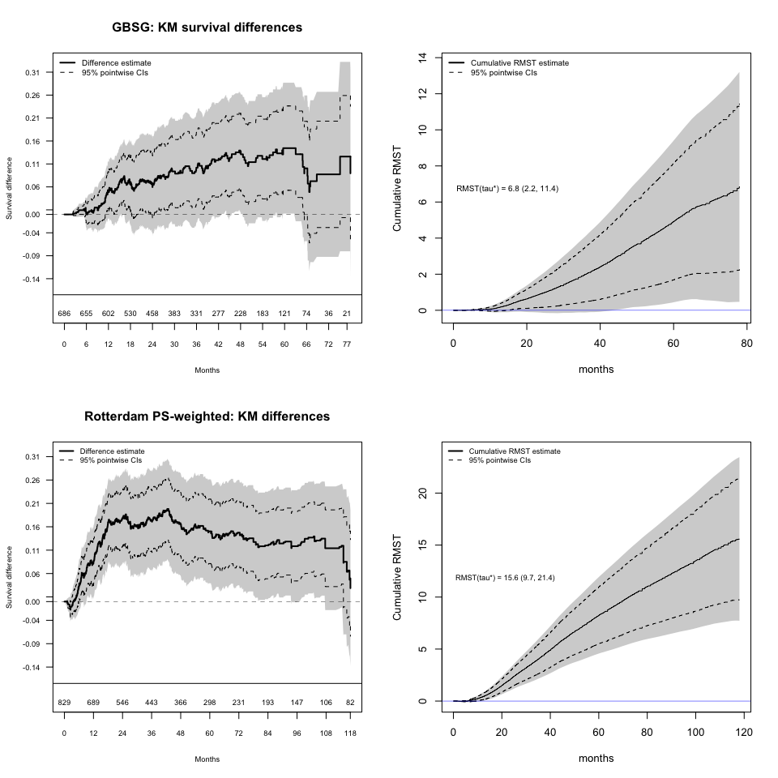

## vignettes/articles/weightedcox_wald-vs-logrank_simulations.Rmd

This file is byte-identical at ac76f82 and at HEAD; it was knitted once, and the same figure is shown on both sides.

### 1.

vignettes/articles/weightedcox_wald-vs-logrank_simulations.Rmd · chunk before: `main-3tests-plot (figure 1)` · chunk after: `main-3tests-plot (figure 1)` · image files byte-identical

Before (ac76f82)

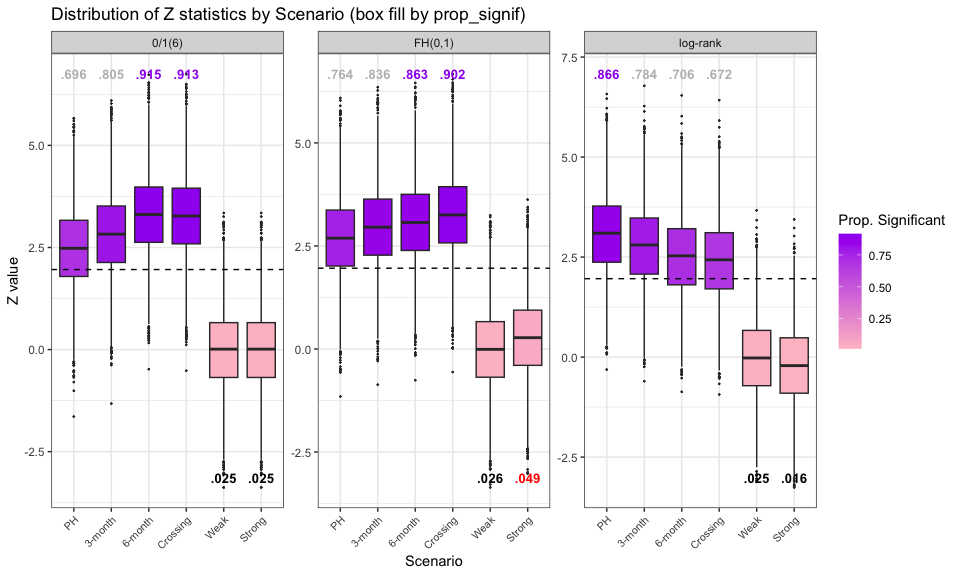

After (HEAD)

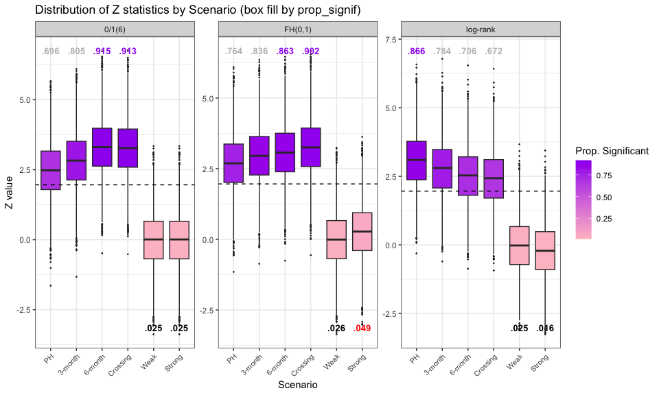

### 2.

vignettes/articles/weightedcox_wald-vs-logrank_simulations.Rmd · chunk before: `all-fh-plot (figure 1)` · chunk after: `all-fh-plot (figure 1)` · image files byte-identical

Before (ac76f82)

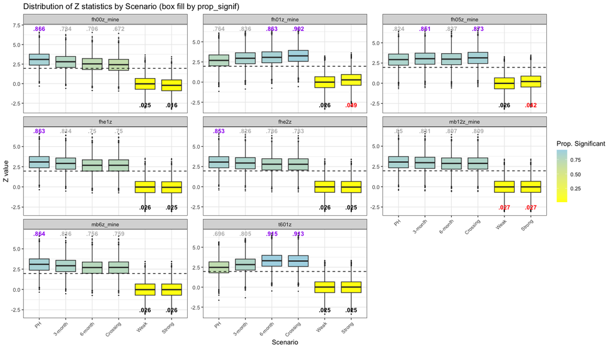

After (HEAD)

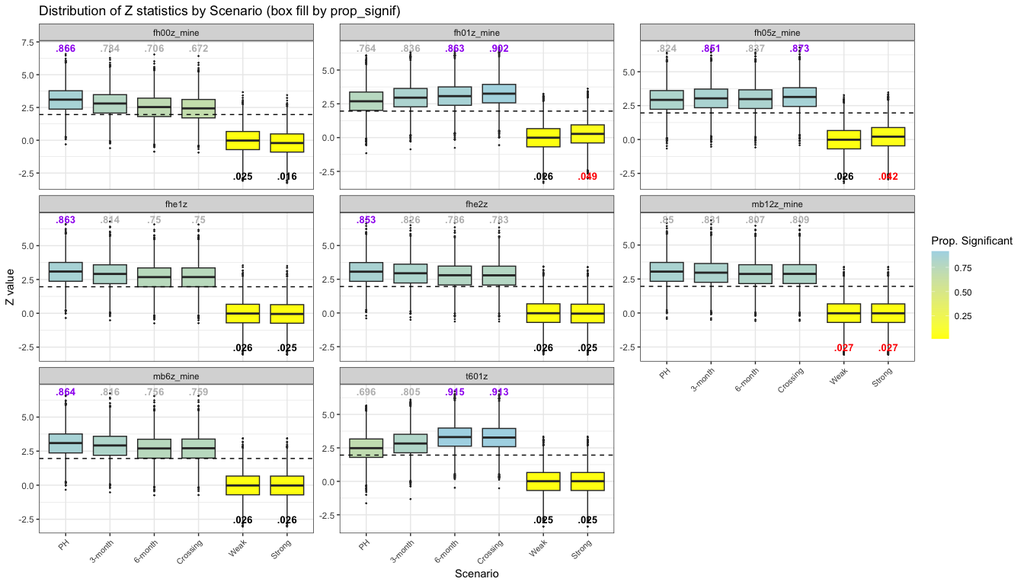

### 3.

vignettes/articles/weightedcox_wald-vs-logrank_simulations.Rmd · chunk before: `simtrial-comparison-plot (figure 1)` · chunk after: `simtrial-comparison-plot (figure 1)` · image files byte-identical

Before (ac76f82)

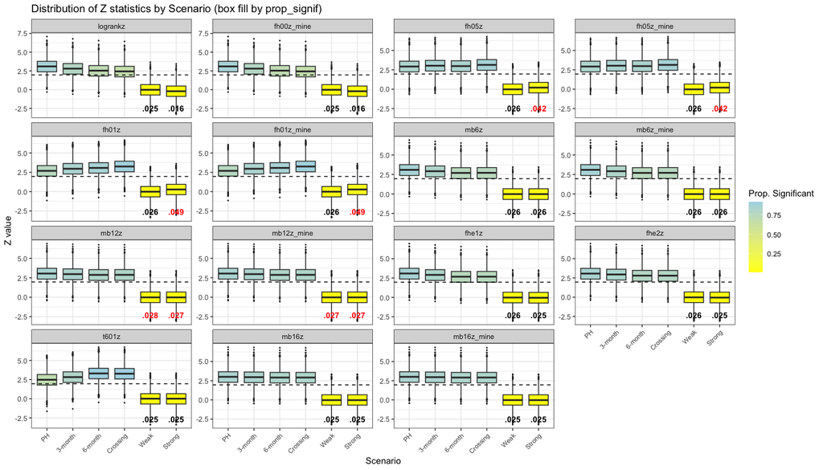

After (HEAD)

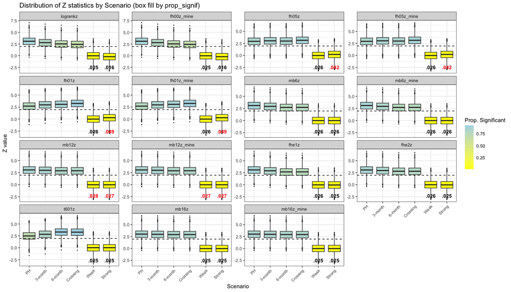